# 4: Normal distributions, correlations

## Interpreting the PDF and CDF

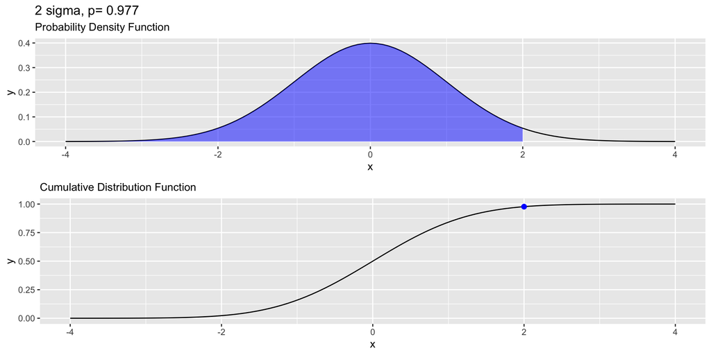

## Interpreting the PDF and CDF

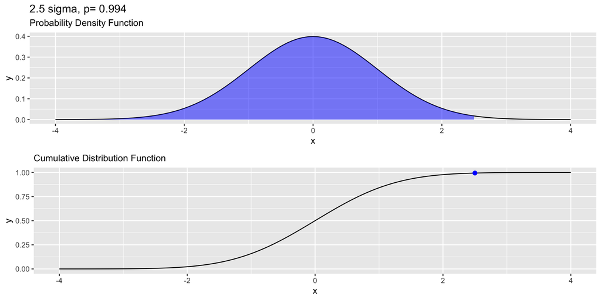

## Interpreting the PDF and CDF

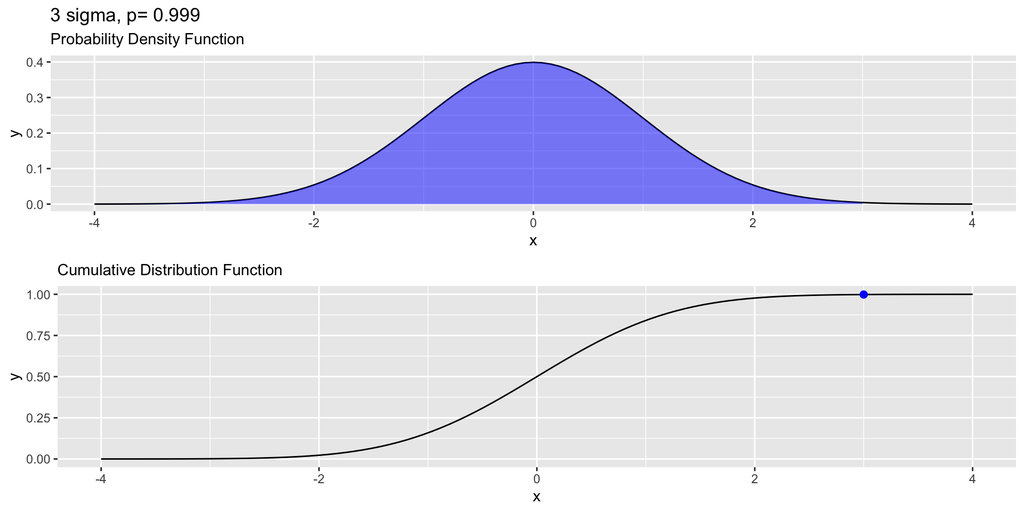

## Z-scores and area under the curve

- To obtain a z-score, we subtract the mean and divide by the standard deviation:

$$\textsf{z-score} = \frac{X-\mu}{\sigma}$$

- For a Normal variable, z-scores are distributed $z \sim N(0,1)$
- What does a z-score of 0 indicate? -1? 2?

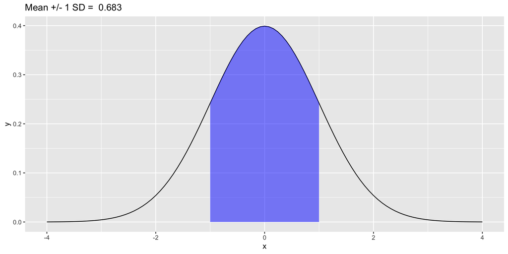

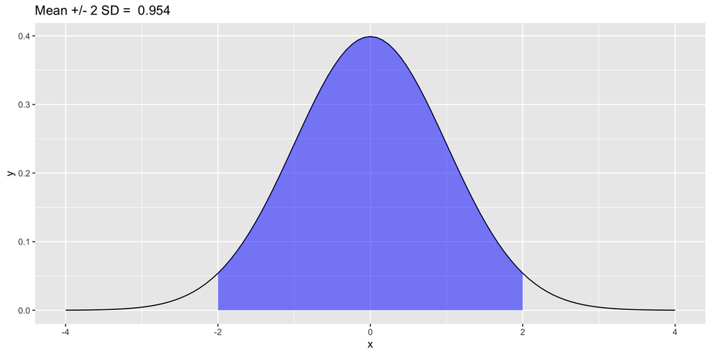

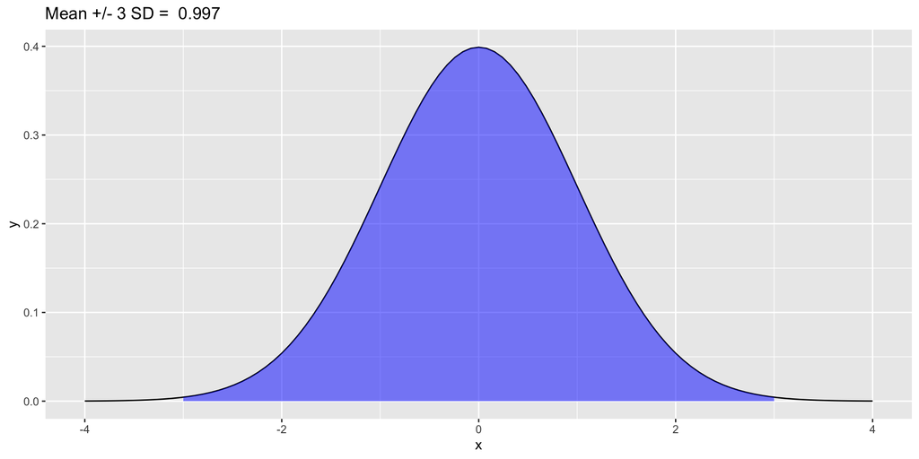

## Special features of Normal distributions:

- The sum of many random variables from other distributions are often Normal
- If X is a Normal random variable, then $Y=X+c$ is also Normal
  - $Y \sim (\mu +c, \sigma^2)$
- It works for multiplication too, as a scaling factor
  - $Y=cX$ is distributed $Y\sim N(c\mu, (c\sigma)^2)$
- Z-scores of a Normal random variable are $N(0,1)$

# Correlation

## Correlation defined

- Correlation measures the linear relationship between two variables $x$ and $y$

$$cor_{xy} = \frac{\textrm{E}[(x-\bar{x})(y-\bar{y})]}{\sigma_x \cdot \sigma_y}$$

## Correlation and Z-scores

- It’s helpful to have measures on the same scale
- A $z$-score measures the number of standard deviations an observation is away from the mean of a variable.
- $z\textrm{ score of }x_i = \frac{x_i-\bar{x}}{S_x}$
- In R, we can transform a numeric into a $z$-score using `scale()`

## Z-scores in R

```r
iris  |>
  mutate(Sepal.Length.sc = scale(Sepal.Length)) |>
  select(Sepal.Length, Sepal.Length.sc)
```

```
    Sepal.Length Sepal.Length.sc
1            5.1     -0.89767388
2            4.9     -1.13920048
3            4.7     -1.38072709
4            4.6     -1.50149039
5            5.0     -1.01843718
6            5.4     -0.53538397
7            4.6     -1.50149039
8            5.0     -1.01843718
9            4.4     -1.74301699
10           4.9     -1.13920048
11           5.4     -0.53538397
12           4.8     -1.25996379
13           4.8     -1.25996379
14           4.3     -1.86378030
```

[output cut: 136 more lines]

## Z-score transformed distributions have the same shape as the original data

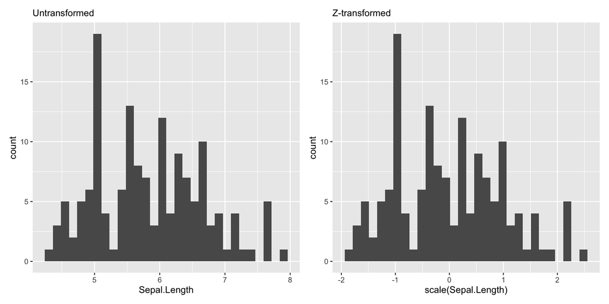

## Correlation

- Correlation measures the linear association between two variables. We often use the letter $r$ to denote a correlation.

$$r(x,y) = \frac{1}{n}\sum_{i=1}^{n} \frac{x_i-\bar{x}}{S_x} \times \frac{y_i-\bar{y}}{S_y}$$

$$= E[z(x) \times z(y)]$$

In R, you can use `cor()`

## Evaluate correlations using cor()

- Compute the correlation between Sepal.Length and Sepal.Width. What does it mean?
- Compute the correlation between Petal.Length and Petal.Width. What does it mean?
- Compute the correlation between Petal.Length and Sepal.Width. What does it mean?

# Interpreting relationships with scatterplots

## Correlation and scatterplots

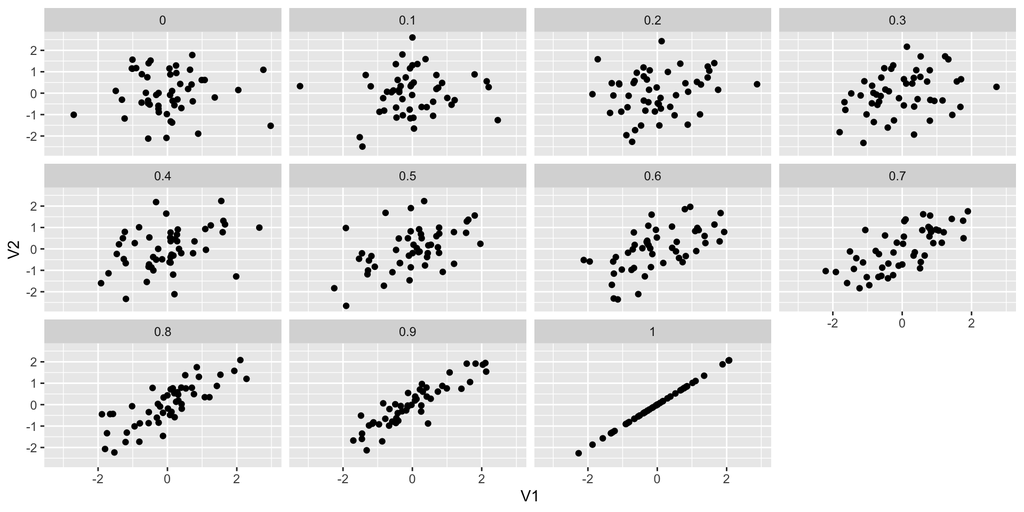

## Correlation and scatterplots

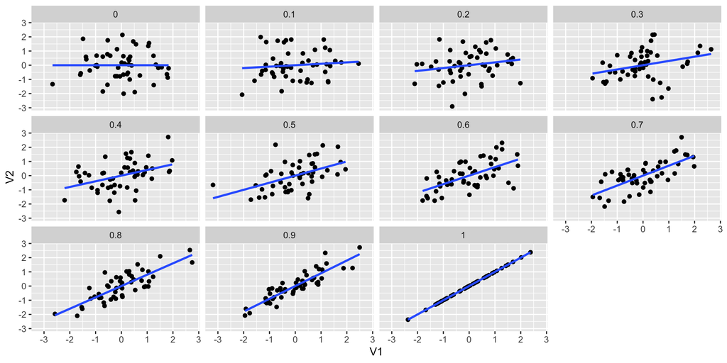

## Correlation and scatterplots

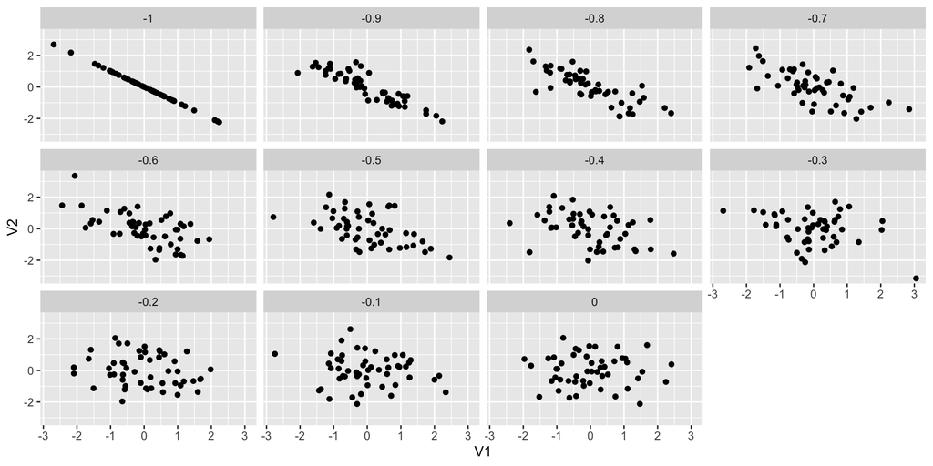

## Correlation and Scatterplots

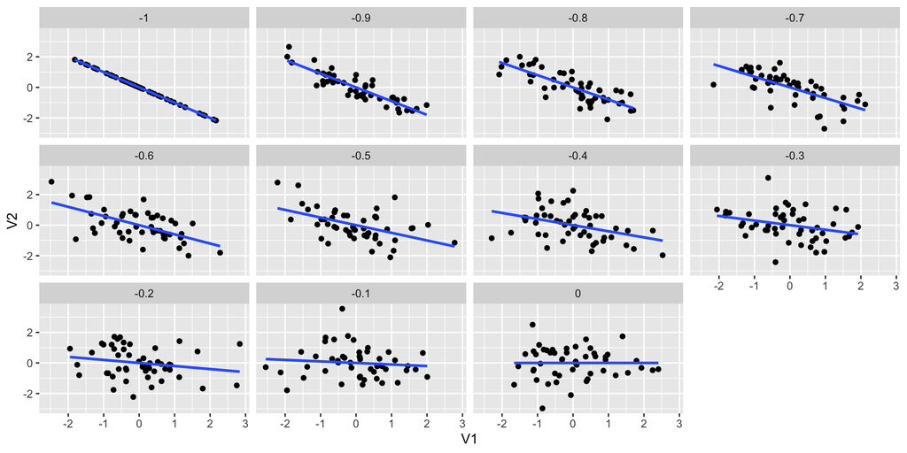

## Return to iris

- Scatterplot Sepal.Width and Petal.Width
- How would you describe the relationship between the variables?
- Estimate the correlation
- Describe what you find using both the estimated correlation and your interpretation of the scatterplot

# Why we visualize

## Exercise

- load `data(“anscombe”)
- Compute correlations for each pair x1, y1; x2, y2; …
- What do you find?
- Now scatterplot each pair using ggplot

## Homework prep

- Download the Uniform Crime Reports Arrests by Age, Sex, and Race 2022 data from NACJD in delimited format: https://www.icpsr.umich.edu/web/NACJD/studies/39063
- Move the data into a subdirectory of your intro_stats folder called ./data/